# Introduccion a R

Diciembre, 2023

## Que es R?

R es un lenguaje de programación y un entorno de software diseñado específicamente para estadísticas y análisis de datos. Fue desarrollado por Ross Ihaka y Robert Gentleman en la Universidad de Auckland, Nueva Zelanda, en la década de 1990. Desde entonces, R se ha convertido en uno de los lenguajes más populares en el ámbito de la estadística y la ciencia de datos

## Características Clave

1. **Estadísticas y Análisis de Datos:** R es potente para realizar análisis estadísticos y exploración de datos, se pueden realizar tareas como regresión, análisis de varianza, machine learning, y más.
2. **Gráficos:** R tiene excelentes capacidades para la visualización de datos. Puedes crear una variedad de gráficos de alta calidad para explorar y comunicar patrones en los datos.
3. **Comunidad y Paquetes:** R tiene una comunidad activa de usuarios y desarrolladores. Además, cuenta con un extenso sistema de paquetes que amplían sus capacidades.
4. **Investigación Académica y Empresarial:** R se utiliza en entornos académicos, de investigación y empresariales
5. **Integración con Otros Lenguajes y Herramientas:** R se puede integrar con otros lenguajes de programación como C, C++, y Python.

## Que es GIT?

**Git** es un sistema de control de versiones distribuido ampliamente utilizado. Fue creado por Linus Torvalds en 2005 y se ha convertido en una herramienta esencial para el desarrollo de software colaborativo.

## Beneficios de Git:

1. **Trabajo Colaborativo:** Git permite a varios desarrolladores trabajar en un proyecto simultáneamente sin temor a conflictos. Cada desarrollador puede trabajar en su propia rama y fusionar los cambios de manera eficiente.
2. **Historial y Auditoría:** El historial completo de cambios en un proyecto proporciona una trazabilidad clara y facilita la identificación de errores o problemas.
3. **Ramificación:** La capacidad de crear ramas fácilmente facilita el desarrollo de nuevas características y la corrección de errores sin afectar la rama principal del proyecto.
4. **Flexibilidad:** Git es flexible y se adapta a diversos flujos de trabajo, pequeños o grandes
5. **Respaldo y Recuperación:** La distribución y duplicación de repositorios proporciona una forma robusta de respaldar y recuperar proyectos en caso de fallos.

## Crear usuario en GIT

- Ir a https://github.com/signup?source=login
- Crear nuevo usuario
- **! Crea un usuario facil de escribir y al mismo tiempo que se vea profesional**
- GIT tambien es un buen portafolio profesional

## Instalacion de R & GIT

### Windows:

#### 1. R:

- Descarga R desde el sitio oficial: https://cran.r-project.org/mirrors.html
- Ejecuta el instalador descargado y sigue las instrucciones.

#### 2. Rtools (opcional pero recomendado para instalar paquetes adicionales):

- Descarga Rtools desde https://cran.r-project.org/bin/windows/Rtools/
- Ejecuta el instalador y sigue las instrucciones.

#### 3. Git:

- Descarga Git desde https://git-scm.com/download/win
- Ejecuta el instalador descargado y sigue las instrucciones.

## Instalacion de R & GIT

### macOS:

#### 1. R:

- Puedes instalar R usando Homebrew con el siguiente comando en la terminal: `bash brew install r`

#### 2. Git:

- Puedes instalar Git usando Homebrew con el siguiente comando en la terminal: `bash brew install git`

## Patalla de R

[figure not shown]

https://bookdown.org/gboccardo/manual-ED-UCH/uso-basico-de-rstudio.html

## Directorios de trabajo

### y comentarios

En R, el directorio de trabajo es el lugar en el sistema de archivos donde R buscará y guardará archivos por defecto.

Comentarios: Proporciona información adicional sobre el propósito o funcionamiento del código #

```r
###### Directorios de trabajo
setwd("~/Documents/GitHub/Intro_R_2023")  #Mac
getwd() #Donde estamos trabajando?
```

```
## [1] "/Users/lio/Documents/GitHub/Intro_R_2023"
```

```r
# Comentarios
# comentario
```

## Paquetes

Los “paquetes” son un conjuntos de herramientas, funciones y datos que extienden la funcionalidad básica del lenguaje.

[figure not shown]

Paquetes

## Paquetes

Los paquetes no se instalan automáticamente con R. Para utilizar un paquete, primero debes instalarlo.

Una vez instalado, debes cargar un paquete en tu sesión de R para poder utilizar sus funciones.

```r
#install.packages("tidyverse")
#install.packages("dplyr")
library(tidyverse)
library(dplyr)
#update.packages() #actualiza todos los paquetes que tengas instalados
```

## ¿Por qué debemos instalar los paquetes?

## Ayuda

En R, el signo de interrogación (?) se utiliza para acceder a la documentación de una función o de un paquete. Al colocar el signo de interrogación seguido del nombre de una función o paquete y ejecutar esa línea de código, R abrirá la documentación correspondiente en la ventana de ayuda.

```r
?print()
?lm #Busqueda Simple
??lm #Busqueda Amplia
```

## Operadores

Los operadores son símbolos o palabras clave que realizan operaciones en variables y valores.

- Operadores de asignación:
- Operadores aritméticos
- Operadores de comparación
- Operadores lógicos

## Operadores

### Operadores de asignación

- Asignación de variables: <- o =

```r
variable <- 42
variable
```

```
## [1] 42
```

## Operadores

### Operadores aritméticos

- Suma: +
- Resta: -
- Multiplicación: *
- División: /
- Potenciación: ^ o **
- Resto de la división entera: %%
- Cociente de la división entera: %/%

## Operadores

### Operadores aritméticos

```r
a <- 10
b <- 3
suma <- a + b
resta <- a - b
multiplicacion <- a * b
division <- a / b

print(suma)
```

```
## [1] 13
```

```r
division
```

```
## [1] 3.333333
```

## Operadores

### Operadores de comparación

- Igual a: ==
- No igual a: !=
- Menor que: <
- Mayor que: >
- Menor o igual que: <=
- Mayor o igual que: >=

```r
x <- 5
y <- 10
resultado <- x > y
print(resultado)
```

```
## [1] FALSE
```

## Operadores

### Operadores lógicos

- AND lógico: &
- OR lógico: |
- NOT lógico: !

```r
condicion1 <- TRUE
condicion2 <- FALSE
resultado <- condicion1 & condicion2
print(resultado)
```

```
## [1] FALSE
```

## Objetos

En el contexto de R, “objetos” se refiere a las estructuras de datos que almacenan información.

- Funciones
- Vectores
- Matrices
- Listas
- Data Frames (Marco de Datos)
- Factores

## Objetos

```r
## Recuerda que R es un lenguaje sensible a mayúsculas y minúsculas
(10 + 2) * 5
```

```
## [1] 60
```

```r
x <- (10 + 2) * 5  # <- es equivalente a =
x <- NA
x <- c(8,9,10,12,14,10,13,10,9)

print(x)
```

```
## [1]  8  9 10 12 14 10 13 10  9
```

## Objetos

### Funciones

Objetos que contienen código ejecutable.

| Informacion | Aritmética | Estadistica | Orden |
| --- | --- | --- | --- |
| summary(x) | min(x) | sd(x) | rev(x) |
| mode(x) | max(x) | var(x) | unique(x) |
| length(x) | log(x) | median(x) | sort(x) |
| range(x) | sum(x) | mean(x) | rev(sort(x)) |

#¿Donde podemos encontrar más funciones?

## Objetos

### Vectores: Clase genérica que permite almacenar una colección de objetos del mismo tipo

- Numericos: Almacenan números reales.
- Enteros: Almacenan números enteros.
- Lógicos: Almacenan valores booleanos (TRUE o FALSE).
- Caracteres: Almacenan texto

```r
# Ejemplos de vectores
numeric_vector <- c(1.5, 2.3, 4.0)
entero_vector <- c(1, 2, 3)
logico_vector <- c(TRUE, FALSE, TRUE)
caracteres_vector <- c("uno", "dos", "tres")
```

## Objetos

### Vectores

```r
peso <- c(60, 72, 57, 90, 95, 72)
altura <- c(1.75, 1.80, 1.65, 1.90, 1.74, 1.91)
imc <- peso/altura^2

print(imc)
```

```
## [1] 19.59184 22.22222 20.93664 24.93075 31.37799 19.73630
```

## Objetos

Matrices: Arreglos bidimensionales de elementos del mismo tipo.

```r
X <- matrix(c(1, 2, 3, 11, 12, 13), nrow=2, ncol=3, byrow=TRUE,
            dimnames=list(c("fila1", "fila2"), c("C.1", "C.2", "C.3")))

X
```

```
##       C.1 C.2 C.3
## fila1   1   2   3
## fila2  11  12  13
```

```r
X <- matrix(c(10, 10, 10, 10, 10, 10), nrow=2, ncol=3, byrow=TRUE,
            dimnames=list(c("fila1", "fila2"), c("C.1", "C.2", "C.3")))
```

## Objetos

### Matrices

```r
rownames(X) #nombre de filas
```

```
## [1] "fila1" "fila2"
```

```r
colnames(X) #nombre de columnas
```

```
## [1] "C.1" "C.2" "C.3"
```

```r
nrow(X) #Numero de filas
```

```
## [1] 2
```

```r
ncol(X) #numero de columnas
```

```
## [1] 3
```

```r
dim(X) #dimensiones
```

```
## [1] 2 3
```

```r
t(X) #trasponer
```

```
##     fila1 fila2
## C.1    10    10
## C.2    10    10
## C.3    10    10
```

## ¿Por qué se muestra la segunda matriz y no la primera?

## Objetos

### Matrices

Manipulacion de Matrices

```r
C.4 <- c(100, 1000) #crear vector para 4ta columna
X1 <- cbind(X, C.4) #Agregar 4ta columna a X
fila3 <- c(10, 100, 1000) #crear fila 3
X2 <- rbind(X, fila3) #agregar fila 3 a X

X2
```

```
##       C.1 C.2  C.3
## fila1  10  10   10
## fila2  10  10   10
## fila3  10 100 1000
```

## Objetos

### Matrices

Manipulacion de Matrices

```r
#Donde se fue la Columna 4 (C.4)?
X2 <- rbind(X, fila3) #agregar fila 3 a X
fila3 <- c(10, 100, 1000, 10000) #crear fila 3
X3 <- rbind(X1, fila3) #agregar fila 3 a X

X3
```

```
##       C.1 C.2  C.3   C.4
## fila1  10  10   10   100
## fila2  10  10   10  1000
## fila3  10 100 1000 10000
```

## Objetos

### Lista

Listas: Colecciones ordenadas de objetos de diferentes tipos.

```r
## Lista (grupos de cualquier tipo de objeto R)

lista_ejemplo <- list(numeric_vector, entero_vector, logico_vector, caracteres_vector)


lista_ejemplo
```

```
## [[1]]
## [1] 1.5 2.3 4.0
##
## [[2]]
## [1] 1 2 3
##
## [[3]]
## [1]  TRUE FALSE  TRUE
##
## [[4]]
## [1] "uno"  "dos"  "tres"
```

```r
lista_ejemplo[[4]]
```

```
## [1] "uno"  "dos"  "tres"
```

## Objetos

### Data Frames

Estructuras de datos bidimensionales similares a las matrices, pero pueden contener columnas de diferentes tipos.

```r
# Ejemplo de data frame
data_frame_ejemplo <- data.frame(
  Nombre = c("Juan", "Maria", "Carlos"),
  Edad = c(25, 30, 22),
  Casado = c(FALSE, TRUE, FALSE)
)
data_frame_ejemplo
```

```
##   Nombre Edad Casado
## 1   Juan   25  FALSE
## 2  Maria   30   TRUE
## 3 Carlos   22  FALSE
```

## Objetos

### Data Frames

Manipulacion de Datos

```r
## Marco de datos (Data Frame)
data <- data.frame(alpha=1:3,
                   beta=4:6, gamma=7:9)
names(data)[3] <- "tres"
data$tres <- NULL

# Reordenar marco de datos
data <- data.frame(id=1:3, peso=c(50, 90, 75),
                   tamaño=c("pequeño", "grande", "mediano"))
data[c(1, 3, 2)]
```

```
##   id  tamaño peso
## 1  1 pequeño   50
## 2  2  grande   90
## 3  3 mediano   75
```

```r
data[c("tamaño", "id", "peso")]
```

```
##    tamaño id peso
## 1 pequeño  1   50
## 2  grande  2   90
## 3 mediano  3   75
```

## Objetos

### Factores

Vectores que representan **variables categóricas** con **niveles** predefinidos.

```r
x <- factor(c("alpha", "beta", "gamma", "alpha", "beta"))
levels(x) #Distintos Valores unicos que puede tomar un factor
```

```
## [1] "alpha" "beta"  "gamma"
```

```r
levels(x)[levels(x)=="beta"] <- "dos" #cambiamos beta por dos
levels(x)[3] <- "tres"  #cambiamos el tercer nivel por tres
levels(x) <- c("uno", "dos", "tres") #cambiamos todos los niveles por el vector
```

## Objetos

### Manipulaciones

```r
# Convertir objetos
data <- as.matrix(data) #Para convertir en Matriz

data
```

```
##      id  peso tamaño
## [1,] "1" "50" "pequeño"
## [2,] "2" "90" "grande"
## [3,] "3" "75" "mediano"
```

## ¿Que tipos de datos hay en la matriz?

## Objetos

### Manipulaciones

```r
# Convertir objetos
data
```

```
##      id  peso tamaño
## [1,] "1" "50" "pequeño"
## [2,] "2" "90" "grande"
## [3,] "3" "75" "mediano"
```

```r
data_1 <- as.numeric(data)
#Para convertir en Matriz

data_1
```

```
## [1]  1  2  3 50 90 75 NA NA NA
```

```r
#Que paso con nuestros datos?
```

## Objetos

### Manipulaciones

```r
# Convertir objetos

typeof(data)
```

```
## [1] "character"
```

```r
data[,3] <- c(1,3,2)

data
```

```
##      id  peso tamaño
## [1,] "1" "50" "1"
## [2,] "2" "90" "3"
## [3,] "3" "75" "2"
```

```r
# Convertir toda la matriz a tipo numérico
data_numeric <- as.numeric(data)

# Remodelar la matriz a sus dimensiones originales
dim(data_numeric) <- dim(data)

data_numeric
```

```
##      [,1] [,2] [,3]
## [1,]    1   50    1
## [2,]    2   90    3
## [3,]    3   75    2
```

## Objetos

### Manipulaciones

```r
x <- 1:20 #Creamos un Objeto
x[3] <- 100 #introducir 100 en el lugar 3

x
```

```
##  [1]   1   2 100   4   5   6   7   8   9  10  11  12  13  14  15  16  17  18  19
## [20]  20
```

```r
x[c(2, 4)] <- 111 #Introcir 111 en el lugar 2 y 4

x
```

```
##  [1]   1 111 100 111   5   6   7   8   9  10  11  12  13  14  15  16  17  18  19
## [20]  20
```

```r
#Que tipo de objeto es x?
```

## Indexacion

La indexación en R se refiere a la forma en que accedemos a elementos específicos en un objeto de datos, como vectores, matrices, listas o data frames.

https://rpubs.com/adiedrichs/basicIndexInR

```r
iris
```

```
##     Sepal.Length Sepal.Width Petal.Length Petal.Width    Species
## 1            5.1         3.5          1.4         0.2     setosa
## 2            4.9         3.0          1.4         0.2     setosa
## 3            4.7         3.2          1.3         0.2     setosa
## 4            4.6         3.1          1.5         0.2     setosa
## 5            5.0         3.6          1.4         0.2     setosa
## 6            5.4         3.9          1.7         0.4     setosa
## 7            4.6         3.4          1.4         0.3     setosa
## 8            5.0         3.4          1.5         0.2     setosa
## 9            4.4         2.9          1.4         0.2     setosa
## 10           4.9         3.1          1.5         0.1     setosa
## 11           5.4         3.7          1.5         0.2     setosa
## 12           4.8         3.4          1.6         0.2     setosa
## 13           4.8         3.0          1.4         0.1     setosa
## 14           4.3         3.0          1.1         0.1     setosa
```

[output cut: 136 more lines]

## Indexacion

http://www.lac.inpe.br/~rafael.santos/Docs/CAP394/WholeStory-Iris.html

## Indexacion

```r
head(iris[3]) #columna 3
```

```
##   Petal.Length
## 1          1.4
## 2          1.4
## 3          1.3
## 4          1.5
## 5          1.4
## 6          1.7
```

```r
head(iris[c(1, 2)])
```

```
##   Sepal.Length Sepal.Width
## 1          5.1         3.5
## 2          4.9         3.0
## 3          4.7         3.2
## 4          4.6         3.1
## 5          5.0         3.6
## 6          5.4         3.9
```

```r
head(iris[1,]) #Numero de fila
```

```
##   Sepal.Length Sepal.Width Petal.Length Petal.Width Species
## 1          5.1         3.5          1.4         0.2  setosa
```

```r
head(iris[,4])#Datos en Columna 4
```

```
## [1] 0.2 0.2 0.2 0.2 0.2 0.4
```

```r
head(iris[15,3])  #Numero de fila y columna
```

```
## [1] 1.2
```

## Indexacion

Creamos dos vectores

```r
Sepalos_largo <- iris$Sepal.Length #en cm
Petalos_largo <- iris$Petal.Length #en cm

#Selleccionar vectores
Sepalos_largo > 6
```

```
##   [1] FALSE FALSE FALSE FALSE FALSE FALSE FALSE FALSE FALSE FALSE FALSE FALSE
##  [13] FALSE FALSE FALSE FALSE FALSE FALSE FALSE FALSE FALSE FALSE FALSE FALSE
##  [25] FALSE FALSE FALSE FALSE FALSE FALSE FALSE FALSE FALSE FALSE FALSE FALSE
##  [37] FALSE FALSE FALSE FALSE FALSE FALSE FALSE FALSE FALSE FALSE FALSE FALSE
##  [49] FALSE FALSE  TRUE  TRUE  TRUE FALSE  TRUE FALSE  TRUE FALSE  TRUE FALSE
##  [61] FALSE FALSE FALSE  TRUE FALSE  TRUE FALSE FALSE  TRUE FALSE FALSE  TRUE
##  [73]  TRUE  TRUE  TRUE  TRUE  TRUE  TRUE FALSE FALSE FALSE FALSE FALSE FALSE
##  [85] FALSE FALSE  TRUE  TRUE FALSE FALSE FALSE  TRUE FALSE FALSE FALSE FALSE
##  [97] FALSE  TRUE FALSE FALSE  TRUE FALSE  TRUE  TRUE  TRUE  TRUE FALSE  TRUE
## [109]  TRUE  TRUE  TRUE  TRUE  TRUE FALSE FALSE  TRUE  TRUE  TRUE  TRUE FALSE
## [121]  TRUE FALSE  TRUE  TRUE  TRUE  TRUE  TRUE  TRUE  TRUE  TRUE  TRUE  TRUE
## [133]  TRUE  TRUE  TRUE  TRUE  TRUE  TRUE FALSE  TRUE  TRUE  TRUE FALSE  TRUE
## [145]  TRUE  TRUE  TRUE  TRUE  TRUE FALSE
```

```r
Sepalos_largo[Sepalos_largo > 6]
```

```
##  [1] 7.0 6.4 6.9 6.5 6.3 6.6 6.1 6.7 6.2 6.1 6.3 6.1 6.4 6.6 6.8 6.7 6.7 6.3 6.1
## [20] 6.2 6.3 7.1 6.3 6.5 7.6 7.3 6.7 7.2 6.5 6.4 6.8 6.4 6.5 7.7 7.7 6.9 7.7 6.3
## [39] 6.7 7.2 6.2 6.1 6.4 7.2 7.4 7.9 6.4 6.3 6.1 7.7 6.3 6.4 6.9 6.7 6.9 6.8 6.7
## [58] 6.7 6.3 6.5 6.2
```

## Indexacion

```r
Petalos_largo[Petalos_largo > 5]
```

```
##  [1] 5.1 6.0 5.1 5.9 5.6 5.8 6.6 6.3 5.8 6.1 5.1 5.3 5.5 5.1 5.3 5.5 6.7 6.9 5.7
## [20] 6.7 5.7 6.0 5.6 5.8 6.1 6.4 5.6 5.1 5.6 6.1 5.6 5.5 5.4 5.6 5.1 5.1 5.9 5.7
## [39] 5.2 5.2 5.4 5.1
```

```r
Petalos_largo[Sepalos_largo > 6 & Petalos_largo > 6]
```

```
## [1] 6.6 6.3 6.1 6.7 6.9 6.7 6.1 6.4 6.1
```

```r
Petalos_largo[Sepalos_largo > 6 & Petalos_largo > 6]
```

```
## [1] 6.6 6.3 6.1 6.7 6.9 6.7 6.1 6.4 6.1
```

## Generacion de Datos

```r
1:10
```

```
##  [1]  1  2  3  4  5  6  7  8  9 10
```

```r
seq(from=1, to=10, by=1)
```

```
##  [1]  1  2  3  4  5  6  7  8  9 10
```

```r
seq(1, 10, 1)
```

```
##  [1]  1  2  3  4  5  6  7  8  9 10
```

```r
seq(length=9, from=1, to=5)
```

```
## [1] 1.0 1.5 2.0 2.5 3.0 3.5 4.0 4.5 5.0
```

```r
seq(1, 3, length=7)
```

```
## [1] 1.000000 1.333333 1.666667 2.000000 2.333333 2.666667 3.000000
```

```r
c(1, 2, 3, 4, 5)
```

```
## [1] 1 2 3 4 5
```

```r
rep(1, 30)
```

```
##  [1] 1 1 1 1 1 1 1 1 1 1 1 1 1 1 1 1 1 1 1 1 1 1 1 1 1 1 1 1 1 1
```

```r
rep(1:3, 10)
```

```
##  [1] 1 2 3 1 2 3 1 2 3 1 2 3 1 2 3 1 2 3 1 2 3 1 2 3 1 2 3 1 2 3
```

## Generacion de Datos

Relevamiento de rindes, (50 parcelas, media de 2,8 t/ha, sd=0,8)

```r
rnorm(50,2.8,0.8) #n = observaciones, mean = media, sd = desviacion standart
```

```
##  [1] 1.8483811 2.8790154 1.7330377 2.6559900 3.1111939 3.7724566 1.2729330
##  [8] 1.5842276 1.7161351 2.6896698 3.5191342 2.0311765 3.6536341 2.8802830
## [15] 2.9679205 2.9121613 4.1449750 3.5316552 3.4092076 2.0848906 2.5947266
## [22] 3.2028632 1.7451748 1.3434630 1.2719802 3.4706638 2.8755047 2.4028110
## [29] 1.7305999 3.8539769 0.7403780 2.8590655 3.0415131 2.6947875 2.5943655
## [36] 3.8384242 0.8570774 2.7698752 3.5077040 3.1255166 3.5568922 3.0973389
## [43] 3.7143858 3.4405415 2.4883342 4.0344132 2.7823896 2.5554817 3.3481331
## [50] 3.1858279
```

```r
#https://www.tutorialspoint.com/r/r_normal_distribution.htm
```

## Generacion de Datos

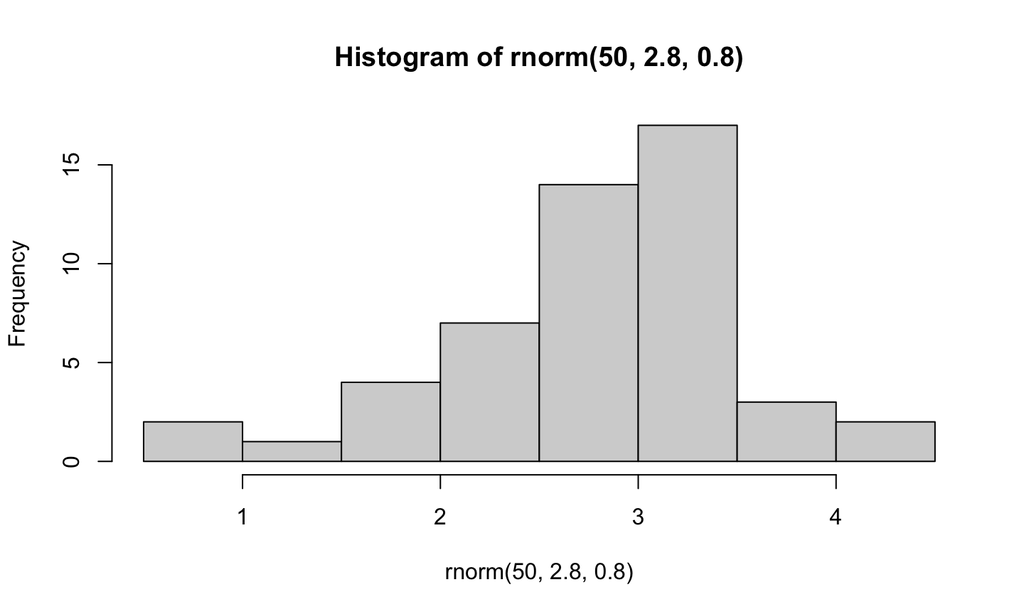

## Graficos

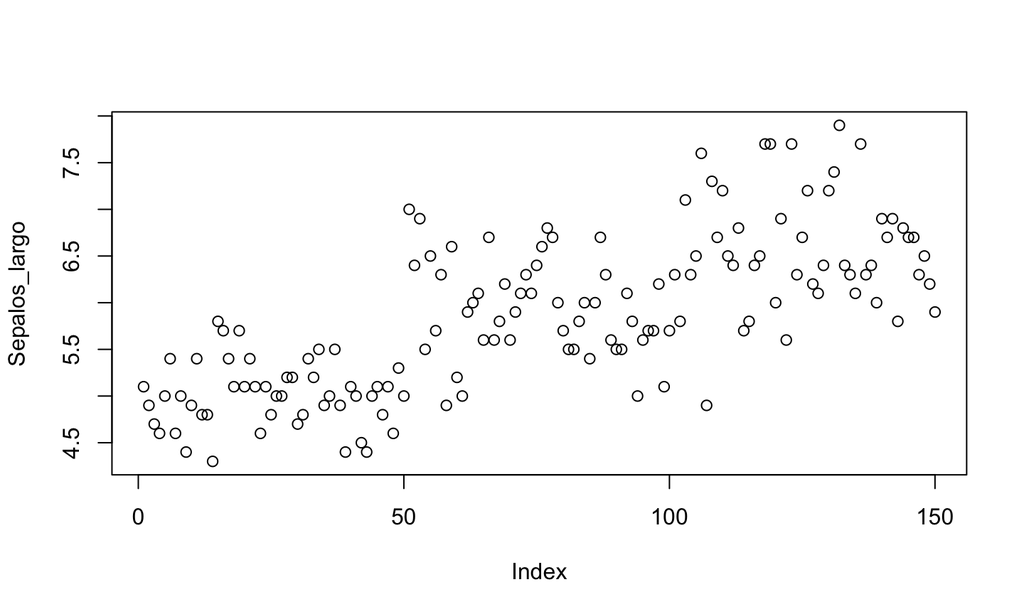

```r
plot(Sepalos_largo)
```

## Graficos

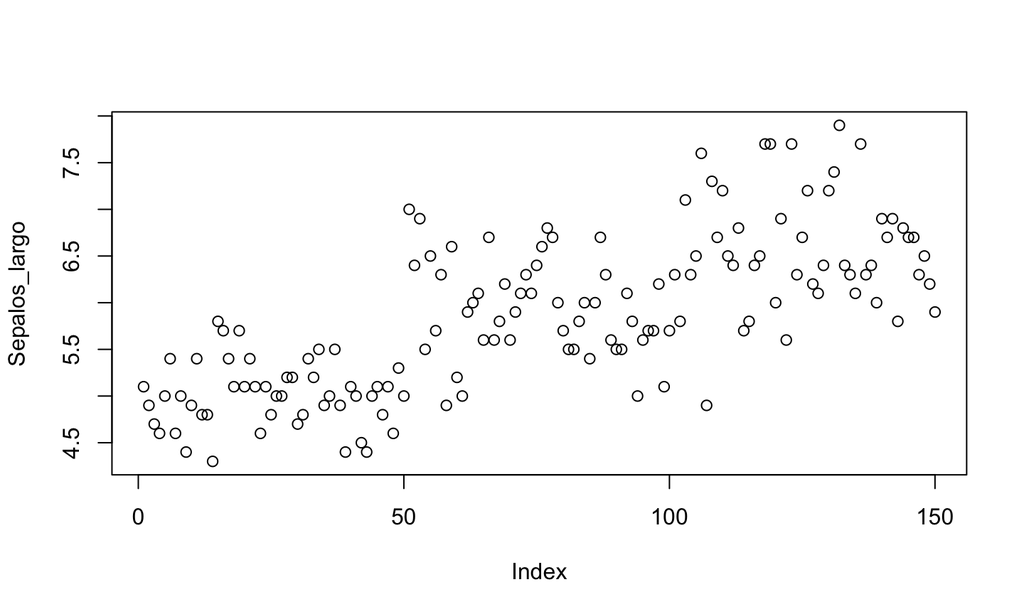

```r
plot(Sepalos_largo, type="p")
```

## Graficos

Relacion Lineal

[figure not shown]

```r
plot(Sepalos_largo~Petalos_largo, main="Iris", xlab="Sepalos (cm)", ylab="Petalos (cm)")
```

## Graficos

histograma

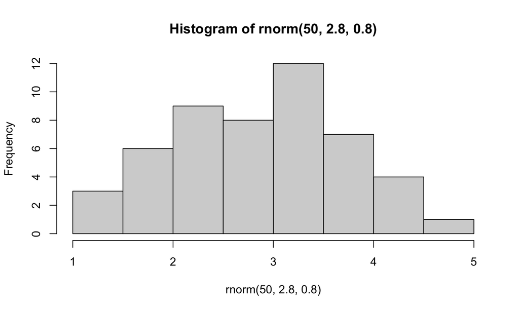

```r
hist(rnorm(50,2.8,0.8))
```

## tidyverse

`tidyverse` es un conjunto de paquetes de R diseñados para trabajar de manera integrada y coherente en el análisis de datos.

[figure not shown]

## Paquetes

### tidyverse

Principales paquetes incluidos en `tidyverse`:

1. **ggplot2**: Para la creación de gráficos y visualizaciones.
2. **dplyr**: Para manipulación y transformación de datos.
3. **tidyr**: Para trabajar con datos en formato “tidy” (ordenados y estructurados).
4. **readr**: Para la importación limpia y eficiente de datos.
5. **purrr**: Para trabajar con funciones y listas de manera más eficiente.
6. **tibble**: Para crear y trabajar con data frames mejorados.

## Beneficios de usar `tidyverse`:

1. **Sintaxis coherente**: Los paquetes en `tidyverse` comparten una sintaxis coherente, lo que facilita aprender y recordar cómo realizar tareas comunes.
2. **Flujo de trabajo eficiente**: `tidyverse` está diseñado para proporcionar un flujo de trabajo eficiente y fácil de entender, desde la importación de datos hasta la visualización de resultados.
3. **Compatibilidad con piped operations**: La tubería `%>%` (pipe) facilita la aplicación de operaciones en secuencia, lo que mejora la legibilidad del código.

## `tidyverse`:

```r
# Instalar y cargar tidyverse
#install.packages("tidyverse")
library(tidyverse)

# Crear un data frame de ejemplo
data <- data.frame(
  ID = c(1, 2, 3, 4, 5),
  Nombre = c("Juan", "María", "Carlos", "Ana", "Pedro"),
  Edad = c(25, 30, 22, 28, 35)
)
```

## `tidyverse`:

```r
# Filtrar personas mayores de 25 años y seleccionar solo las columnas de ID y Nombre
resultado <- data %>%
  filter(Edad > 25) %>%
  select(ID, Nombre)

# Imprimir el resultado
print(resultado)
```

```
##   ID Nombre
## 1  2  María
## 2  4    Ana
## 3  5  Pedro
```

```r
#https://rpubs.com/paraneda/tidyverse
```

## Practica

## Leer Datos

```r
## La separación decimal en R es . y no ,
#Datos en Millones de Guaranies
Ingreso <- read.csv("Datos/IngresoPromPoblacion_py.csv")
Ingreso <- read.table("Datos/IngresoPromPoblacion_py.csv", header=T,
                    na.strings = "4/", sep= ";", check.names = FALSE)

Ingreso
```

```
##     Departamento  1998  1999  2001  2002  2003  2004  2005  2006  2007  2008
## 1  Alto Paraguay    NA    NA    NA    NA    NA    NA    NA    NA    NA    NA
## 2    Alto Parana 3.467 2.716 2.829 2.345 2.392 2.512 2.511 2.136 2.649 2.760
## 3        Amambay    NA    NA    NA    NA 1.545 1.633    NA    NA    NA    NA
## 4       Asuncion 3.964 3.772 3.660 2.978 3.248 3.251 2.978 3.171 2.943 2.749
## 5       Boqueron    NA    NA    NA    NA    NA    NA    NA    NA    NA    NA
## 6       Caaguazu 1.398 1.488 1.484 1.480 1.734 1.444 1.325 1.336 1.355 1.545
## 7        Caazapa    NA    NA    NA    NA 1.334 1.195    NA    NA    NA    NA
## 8      Canindeyu    NA    NA    NA    NA 2.013 1.871    NA    NA    NA    NA
## 9        Central 2.886 2.624 2.385 1.905 1.959 1.879 2.003 1.956 1.934 2.073
## 10    Concepcion    NA    NA    NA    NA 1.504 1.619    NA    NA    NA    NA
## 11    Cordillera    NA    NA    NA    NA 1.317 1.074    NA    NA    NA    NA
## 12        Guaira    NA    NA    NA    NA 1.209 1.309    NA    NA    NA    NA
## 13        Itapua 2.071 2.277 1.576 1.356 1.868 2.141 1.726 1.477 1.403 2.050
## 14      Misiones    NA    NA    NA    NA 1.394 1.039    NA    NA    NA    NA
```

[output cut: 23 more lines]

## Examinar Datos

```r
##Revisar Datos
head(Ingreso) #Primeros datos
tail(Ingreso) #Ultimos Datos
dim(Ingreso) #Tamaño
names(Ingreso) #Nombre de Columnas
summary(Ingreso) #Sumario de Datos
```

## ¿Que departamento tiene el mayor ingreso promedio?

## ¿Que departamento tiene el mayor ingreso promedio?

```r
#Cambiar a datos largos
dato_largo <- Ingreso %>%
  gather(key = "year", value = "Cantidad", -Departamento) %>%
  mutate(year = as.integer(year))

dato_largo
```

```
##      Departamento year Cantidad
## 1   Alto Paraguay 1998       NA
## 2     Alto Parana 1998    3.467
## 3         Amambay 1998       NA
## 4        Asuncion 1998    3.964
## 5        Boqueron 1998       NA
## 6        Caaguazu 1998    1.398
## 7         Caazapa 1998       NA
## 8       Canindeyu 1998       NA
## 9         Central 1998    2.886
## 10     Concepcion 1998       NA
## 11     Cordillera 1998       NA
## 12         Guaira 1998       NA
## 13         Itapua 1998    2.071
## 14       Misiones 1998       NA
```

[output cut: 346 more lines]

## ¿Que departamento tiene el mayor ingreso promedio?

```r
#Limpiar Datos
# Recortar espacios en blanco en columnas
dato_largo$Departamento <- str_trim(dato_largo$Departamento)

# Reemplzar espacios en blanco en columnas
dato_largo$Departamento <- str_replace(dato_largo$Departamento, ' ', '_')

# Reemplazar ciertos valores
any(is.na(dato_largo))  # Verificar valores faltantes (NAs)
```

```
## [1] TRUE
```

```r
#dato_largo[is.na(dato_largo)] <- 0  # Reemplazar NAs con 0s
```

## ¿Que departamento tiene el mayor ingreso promedio?

```r
# Agrupar los datos por departamento y encontrar el departamento con el mayor ingreso promedio
Mayor_Departamento <- dato_largo %>%
  group_by(Departamento) %>%
  summarize(Cantidad_total = mean(Cantidad, na.rm = TRUE)) %>%
  slice(which.max(Cantidad_total)) %>%
  ungroup()
```

## ¿Que departamento tiene el mayor ingreso promedio?

```
## # A tibble: 1 × 2
##   Departamento Cantidad_total
##   <chr>                 <dbl>
## 1 Boqueron               4.55
```

## Otras Preguntas

```r
#Departamentos con ingresos mayor a 2.5 luego del 2000
resultados <- dato_largo %>%
  filter(Cantidad > 2.5 & year > 2000) %>%
  select(Departamento, year, Cantidad)

resultados
```

```
##    Departamento year Cantidad
## 1   Alto_Parana 2001    2.829
## 2      Asuncion 2001    3.660
## 3      Asuncion 2002    2.978
## 4      Asuncion 2003    3.248
## 5   Alto_Parana 2004    2.512
## 6      Asuncion 2004    3.251
## 7   Alto_Parana 2005    2.511
## 8      Asuncion 2005    2.978
## 9      Asuncion 2006    3.171
## 10  Alto_Parana 2007    2.649
## 11     Asuncion 2007    2.943
## 12  Alto_Parana 2008    2.760
## 13     Asuncion 2008    2.749
## 14     Asuncion 2009    2.688
```

[output cut: 31 more lines]

## Graficar

[figure not shown]

## Otras Preguntas

```r
#Seleccionar Solo datos de Itapua
dato_largo_itapua <- dato_largo[dato_largo$Departamento == "Itapua", ]
Ingreso_Promedio_itapua <-  dato_largo_itapua$Cantidad

#Seleccionar Solo datos de Itapua
dato_largo_Boqueron <- dato_largo[dato_largo$Departamento == "Boqueron", ]
Ingreso_Promedio_Boqueron <-  dato_largo_Boqueron$Cantidad
```